# Final Report

2025-12-3

# Energy Insecurity and Mental Distress in the United States: Final Report

## 1. Introduction

This study investigates the relationship between household energy insecurity and population mental health across U.S. states. Energy insecurity—limited access to affordable, reliable energy for heating, cooling, and powering homes—may contribute to chronic stress and poor mental health outcomes. Using 2020 data from the Residential Energy Consumption Survey (RECS) and CDC PLACES datasets, we analyze state-level associations between energy challenges and mental distress.

## 2. Dataset Description and Cleaning Protocol

### Research Motivation

Mental health is a critical component of public health, significantly influencing individual well-being and broader social stability. While traditional determinants such as physical health, income, employment, and social isolation have been extensively studied, this research adopts a novel perspective by examining how **energy insecurity** impacts mental health outcomes. Limited access to affordable, reliable energy—manifested through high utility costs or the inability to maintain adequate heating and cooling—can induce chronic stress, disrupt sleep, and exacerbate anxiety. Using 2020 data from the U.S. Energy Information Administration’s Residential Energy Consumption Survey (RECS) and the Centers for Disease Control and Prevention’s PLACES dataset, this study explores the relationship between household-level energy insecurity and population-level mental distress across U.S. states.

### Dataset Description

#### Dataset Overview

Our analysis integrates two nationally representative datasets offering complementary insights:

1. **Residential Energy Consumption Survey (RECS)**: Captures household-level energy insecurity indicators.
2. **CDC PLACES Data**: Provides community-level mental and physical health prevalence estimates.

The temporal alignment (2020 reference period) and comprehensive geographic coverage of both datasets enable a robust state-level analysis of the association between energy insecurity and mental distress.

#### 1. Residential Energy Consumption Survey (RECS)

##### 1.1 Background and Methodology

The **Residential Energy Consumption Survey (RECS)** is administered by the U.S. Energy Information Administration (EIA) to collect energy characteristics, consumption patterns, and associated costs for housing units across the United States. The 2020 RECS represents the 15th iteration of this survey, first conducted in 1978.

**Key Survey Features:**

- **Collection Period**: 2020
- **Sample Size**: Approximately 18,500 households
- **Population Represented**: 123.5 million occupied housing units
- **Collection Method**: Transitioned from in-person to web/mail surveys with utility data linkage
- **Data Integration**: Combines self-reported survey data with actual energy consumption data from utility providers

The survey employs a multi-stage area probability design to select housing units, ensuring national representativeness. Sample weights (`nweight`) are provided to generate population-level estimates.

##### 1.2 Energy Insecurity Operationalization

Energy insecurity in RECS 2020 is measured through multiple complementary indicators capturing different dimensions of household energy challenges:

| Dimension | Specific Indicators | Measurement Approach |
| --- | --- | --- |
| **Financial Strain** | Choosing between energy bills and basic needs | `SCALEB`, `SCALEG`, `SCALEE` scales |
| **Temperature Control** | Inability to maintain safe/healthy home temperatures | `COLDMA`, `HOTMA` indicators |
| **Service Disruptions** | Utility disconnection notices or service interruptions | Disconnection notice variables |
| **Equipment Limitations** | Unable to use heating/cooling equipment due to: |  |
|  | - Equipment breakdown with financial constraints | `NOHEATBROKE`, `NOACBROKE` |
|  | - Utility service disruption due to non-payment | `NOHEATEL`, `NOHEATNG` |
|  | - Inability to afford bulk fuel delivery | `NOHEATBULK` |
| **Extended Outages** | Power outages lasting 24+ hours | Duration variables |

##### 1.3 Key Variables for Analysis

###### Identification and Weighting Variables

- **`DOEID`**: Unique household identifier
- **`state_name`**: Geographic location (state)
- **`nweight`**: Final sample weight for population estimates

###### Energy Insecurity Indicators

- **Financial Burden**: `SCALEB`, `SCALEG`, `SCALEE` (energy affordability scales)
- **Payment Difficulty**: `PAYHELP` (difficulty paying energy bills)
- **Equipment Issues**: `NOHEATBROKE`, `NOACBROKE` (broken heating/cooling)
- **Fuel Disruptions**: `NOHEATEL`, `NOHEATNG`, `NOHEATBULK` (heating fuel issues)
- **Duration Measures**: `NOHEATDAYS`, `NOACDAYS` (days without heating/cooling)
- **Temperature Control**: `COLDMA`, `HOTMA` (maintaining unsafe temperatures)
- **Assistance Programs**: `ENERGYASST` series (energy assistance participation)

###### Derived Energy Insecurity Measures

From these indicators, we calculate two primary outcome measures:

1. **Energy Insecurity (`EI_number`, `EI_proportion`)**:
   - Number (in millions) and percentage of housing units experiencing energy insecurity
   - Definition includes: forgoing food/medicine for energy bills, maintaining unsafe temperatures, receiving disconnection notices, and being unable to use heating/cooling equipment due to financial constraints or supply disruptions
2. **Extended Power Outages (`PO_number`, `PO_proportion`)**:
   - Number (in millions) and percentage of housing units experiencing power outages lasting 24 hours or more

#### 2. CDC PLACES: Census Tract Health Data

##### 2.1 Dataset Overview

The **PLACES** dataset provides model-based census tract-level estimates for chronic disease risk factors, health outcomes, and clinical preventive service use across the United States. Developed by the Centers for Disease Control and Prevention (CDC), Division of Population Health, this dataset enables local public health assessment and planning.

**Key Dataset Features:**

- **Release Year**: 2022 (using 2020 BRFSS data as primary source)
- **Geographic Coverage**: All 50 states and District of Columbia
- **Geographic Levels**: County, place, census tract, and ZIP Code Tabulation Areas
- **Total Observations**: 72,337 census tracts
- **Funding**: Robert Wood Johnson Foundation in conjunction with the CDC Foundation

##### 2.2 Methodology and Data Sources

PLACES employs a multilevel regression and post-stratification (MRP) approach to generate small-area estimates. The model integrates:

- **Primary Source**: Behavioral Risk Factor Surveillance System (BRFSS) 2020 data for 25 measures (2021 data for 4 biennial measures)
- **Population Data**: U.S. Census Bureau 2020 population estimates
- **Socioeconomic Covariates**: American Community Survey (ACS) 2015–2019 estimates

**Important Note**: These are model-based estimates designed for surveillance and planning purposes. The CDC cautions against using them for program evaluation due to the model’s inability to detect effects of local interventions.

##### 2.3 Health Measures Included

The dataset includes 40 measures across six domains. For our analysis, we focus primarily on mental health indicators while retaining relevant covariates:

###### Primary Mental Health Outcome

- **`mhlth_crude_prev`**: Crude prevalence of poor mental health (percentage of adults reporting ≥14 days of poor mental health in past 30 days)

###### Additional Health Measures (Selected as Covariates)

| Category | Variables | Purpose in Analysis |
| --- | --- | --- |
| **Mental Health** | `depression_crude_prev` | Secondary mental health outcome |
| **Physical Health** | `phlth_crude_prev`, `ghlth_crude_prev` | Health status controls |
| **Chronic Diseases** | `arthritis_crude_prev`, `bphigh_crude_prev`, `diabetes_crude_prev`, `cancer_crude_prev`, `casthma_crude_prev`, `chd_crude_prev`, `copd_crude_prev`, `highchol_crude_prev`, `kidney_crude_prev`, `stroke_… | Comorbidity controls |
| **Health Behaviors** | `binge_crude_prev`, `csmoking_crude_prev`, `lpa_crude_prev`, `obesity_crude_prev`, `sleep_crude_prev` | Behavioral risk factor controls |
| **Preventive Care** | `access2_crude_prev`, `checkup_crude_prev`, `cholscreen_crude_prev`, `colon_screen_crude_prev`, `dental_crude_prev` | Healthcare access controls |
| **Oral Health** | `teethlost_crude_prev` | Additional health indicator |

###### Geographic Identifiers

- **`tract_fips`**: Census tract FIPS code
- **`state_desc`**: State name
- **`county_name`**: County name
- **`county_fips`**: County FIPS code
- **`total_population`**: Population count for the tract
- **`long`**, **`lat`**: Geographic coordinates

### Data Cleaning Protocol

#### 1. RECS Data Processing

##### Step 1: Variable Selection and Extraction

We extracted variables relevant to energy insecurity measurement, household identification, and geographic location from the RECS dataset.

##### Step 2: Energy Insecurity Classification

Households were classified as “energy insecure” if they reported **any** of the following:

1. Forgoing food or medicine to pay energy bills
2. Maintaining home at unsafe or unhealthy temperature
3. Receiving a disconnection notice
4. Being unable to use heating/cooling equipment due to:
   - Broken equipment with financial constraints for repairs
   - Utility service disruption due to non-payment
   - Inability to afford bulk fuel delivery

##### Step 3: Missing Data Imputation

We employed **hot-deck imputation** to address missing values while preserving data integrity:

1. **Donor Matching**: Recipient households with missing values were matched to similar donor households with complete data based on housing characteristics and energy usage patterns
2. **Range Constraints**: Square-footage range responses informed donor selection when available
3. **Distribution Preservation**: Imputed values were constrained within reported ranges to maintain original variable distributions

This approach minimizes bias while utilizing all available information in the dataset.

##### Step 4: State-Level Aggregation

Using sample weights (`nweight`), we aggregated household-level data to generate state-level estimates:

- Weighted counts of energy insecure households
- State-level proportions of energy insecurity
- Similar calculations for extended power outages

#### 2. PLACES Data Processing

##### Step 1: Missing Data Assessment and Handling

Our initial analysis revealed:

- **Total Missing**: 2,235 out of 72,337 records (3.09%)
- **Missing Pattern**: 89.44% of missing cases (1,999 records) lacked blood pressure and cholesterol measurements
- **Decision**: Implemented complete-case analysis by removing records with any missing values

**Rationale**: The low overall missingness rate and concentrated pattern in specific variables justified listwise deletion, as it simplifies analysis without substantially reducing statistical power.

##### Step 2: Variable Selection

We selected variables based on their relevance to our research question:

- **Primary Outcome**: `mhlth_crude_prev` (poor mental health prevalence)
- **Potential Confounders**: Chronic disease prevalence, health behaviors, healthcare access measures
- **Geographic Identifiers**: State, county, and tract information for aggregation

##### Step 3: State-Level Aggregation

We calculated population-weighted averages at the state level:

- Weighted by `total_population` to account for varying tract sizes
- Generated state-level prevalence estimates for all health measures
- Ensured compatibility with RECS state-level data

#### 3. Dataset Integration

##### Step 1: Geographic Harmonization

- Standardized state names across datasets
- Verified consistent state representation (50 states + District of Columbia)
- Created common geographic identifiers for merging

##### Step 2: Final Merged Dataset

The cleaned and integrated dataset contains:

- **51 observations** (50 states + District of Columbia)
- **Key Variables**:
  - State-level energy insecurity estimates from RECS
  - State-level mental health prevalence from PLACES
  - Covariates for potential confounding control
- **Format**: Ready for exploratory analysis, visualization, and regression modeling

## 3. Exploratory Data Analysis

### 3.1 Energy Insecurity Distribution

**Summary Statistics:** - **Energy Insecurity (EI)**: Mean = 25.6% (Range: 15% to 40%) - **Power Outages (PO)**: Mean = 18.2% (Range: 4% to 60%)

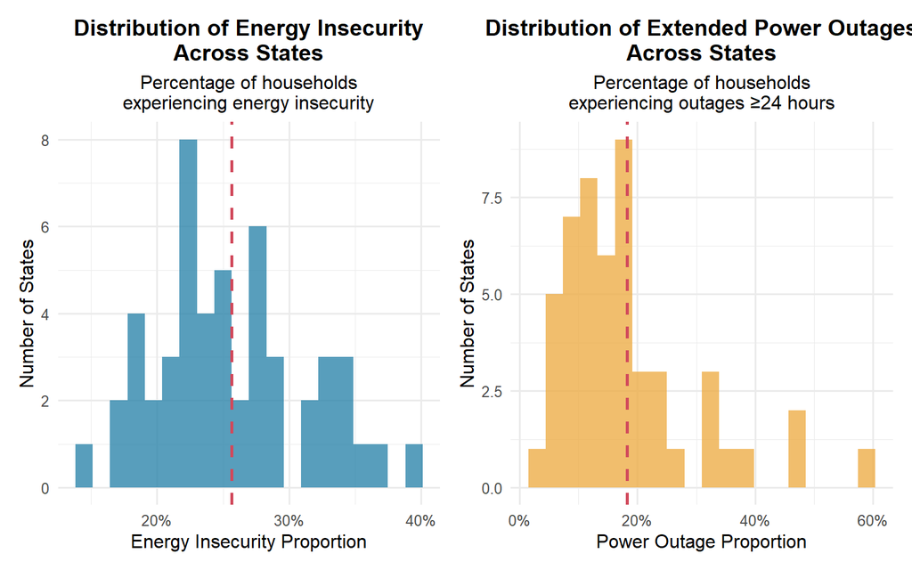

### 3.2 Relationship Between EI and PO

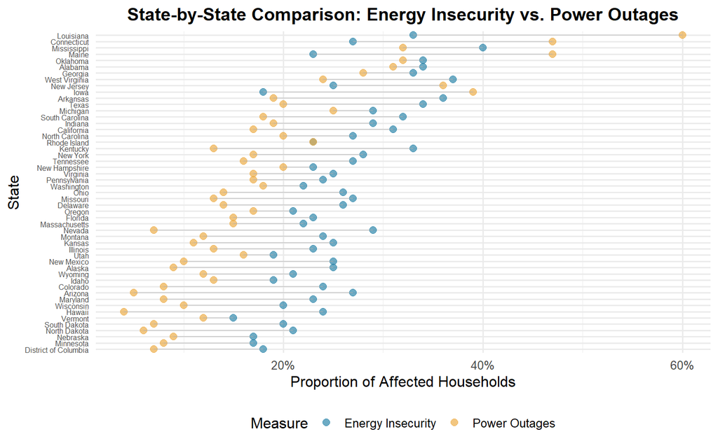

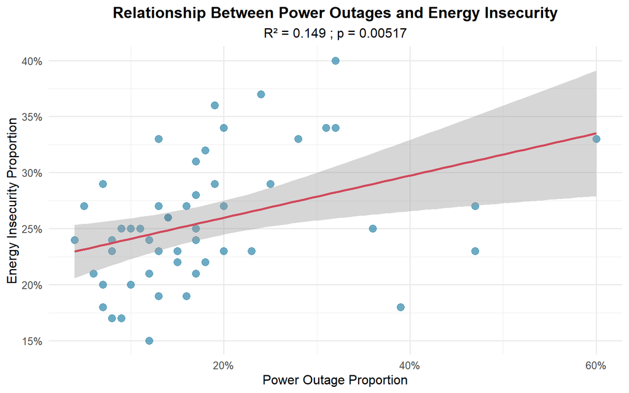

**Interpretation**: There is a weak positive relationship between power outages and energy insecurity (R² = 0.149). This suggests that while outages contribute to energy insecurity, they are not the primary driver—other factors like affordability and housing conditions likely play larger roles.

### 3.3 Mental Health Distribution

**Mental Health Summary:** - **Poor Mental Health**: Mean = 15.2% (Range: 6.1% to 33%) - **Depression**: Mean = 20.5% (Range: 8.5% to 36.8%)

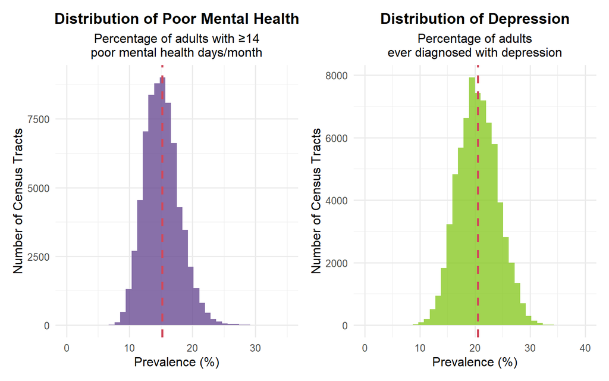

### 3.4 Energy Insecurity and Mental Health Association

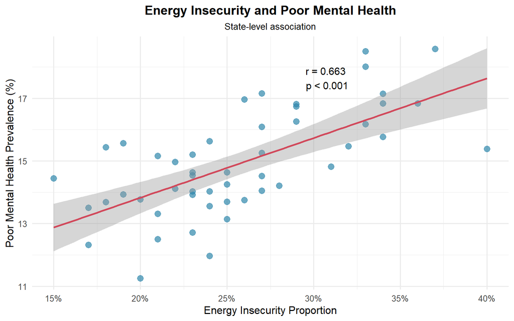

**Key Finding**: There is a strong positive correlation (r = 0.663, p < 0.001) between state-level energy insecurity and poor mental health prevalence. States with higher energy insecurity tend to have worse mental health outcomes.

### 3.5 Distribution of Health Indicators Across Census Tracts

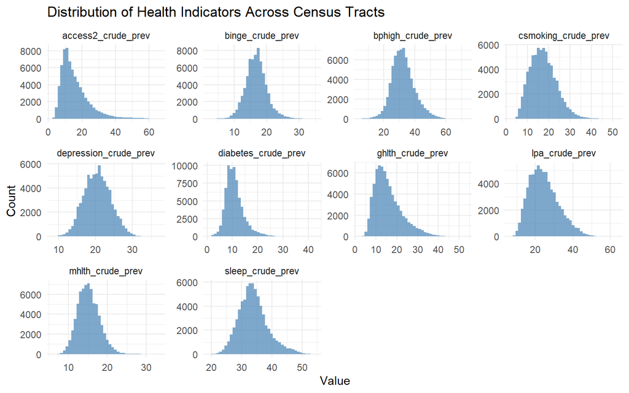

**Pattern**:Across census tracts, health indicators vary widely in their distributions. Some measures are tightly clustered, while others show broader or right-skewed patterns. This variation illustrates unequal health burdens across communities and motivates comparing these indicators across states by energy insecurity levels.

### 3.6 Health Indicators Across EI Groups

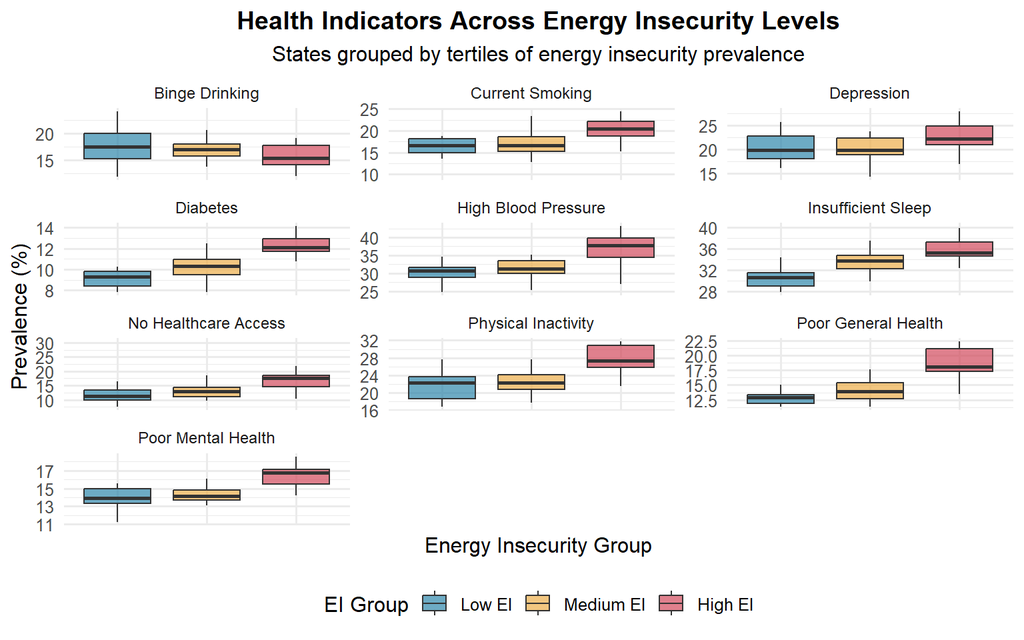

## 4. Regression Analysis

### 4.1 Model Preparation

### 4.2 Multiple Linear Regression

Multiple Linear Regression Results (Full Model)

| term | estimate | conf.low | conf.high | p.value | significance |
| --- | --- | --- | --- | --- | --- |
| mhlth | 0.558 | 0.263 | 0.854 | 0.000 | *** |
| depression | 0.008 | -0.134 | 0.149 | 0.914 |  |
| access2 | 0.029 | -0.041 | 0.099 | 0.413 |  |
| csmoking | -0.021 | -0.172 | 0.130 | 0.780 |  |
| binge | 0.004 | -0.101 | 0.109 | 0.939 |  |
| sleep | -0.101 | -0.225 | 0.024 | 0.110 |  |
| lpa | 0.224 | 0.080 | 0.369 | 0.003 | ** |
| diabetes | 0.671 | 0.287 | 1.055 | 0.001 | ** |
| bphigh | 0.033 | -0.111 | 0.178 | 0.643 |  |
| EI_proportion | 12.789 | 5.606 | 19.971 | 0.001 | *** |
| PO_proportion | -2.130 | -4.270 | 0.011 | 0.051 |  |

### 4.3 Elastic Net Regularization

Elastic Net Model Coefficients

| variable | coefficient |
| --- | --- |
| (Intercept) | -7.217 |
| mhlth | 0.487 |
| depression | 0.005 |
| access2 | 0.046 |
| csmoking | 0.027 |
| lpa | 0.194 |
| diabetes | 0.535 |
| bphigh | 0.032 |
| EI_proportion | 10.817 |
| PO_proportion | -0.819 |

### 4.4 Model Comparison via Cross-Validation

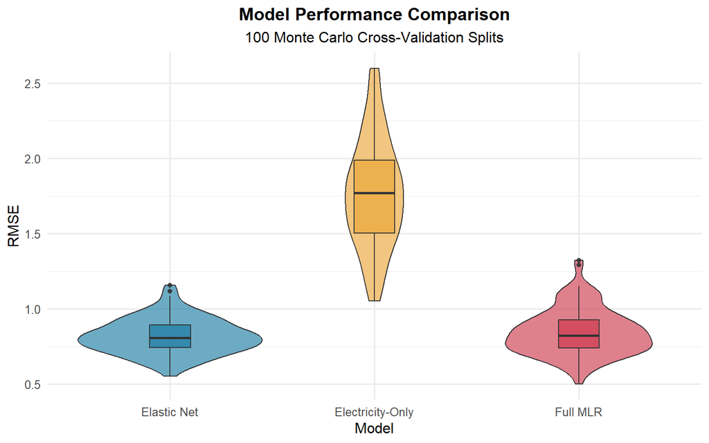

**Model Performance Summary:** - **Elastic Net** achieves the lowest RMSE (most stable predictions) - **Full MLR** shows moderate performance with some variability - **Electricity-only model** has highest RMSE, confirming energy variables alone are insufficient

### 4.5 Bootstrap Stability Analysis

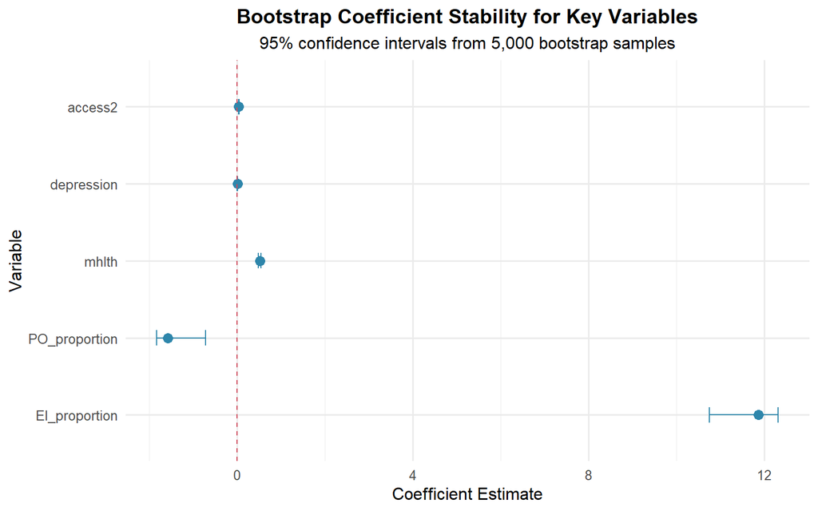

## 5. Discussion and Conclusion

### 5.1 Synthesis of Key Findings

Our comprehensive analysis reveals a complex interplay between energy insecurity, power infrastructure challenges, and population health outcomes across U.S. states. The evidence converges on several critical insights:

**5.1.2 Strong Association Between Energy Insecurity and Mental Health** The correlation analysis reveals a robust positive relationship (r = 0.663, p < 0.001) between state-level energy insecurity and poor mental health prevalence. States with higher energy insecurity consistently exhibit worse mental health outcomes across multiple indicators. This association remains evident even after accounting for power outages, suggesting energy insecurity’s impact extends beyond mere service interruptions to include affordability concerns, housing quality issues, and the psychological burden of energy poverty.

This pattern suggests energy insecurity operates not merely as an isolated stressor but as a marker of broader socioeconomic vulnerability that manifests across multiple health domains.

### 5.2 Mechanistic Interpretation

The observed associations likely reflect several interconnected pathways:

**5.2.1 Direct Stress Pathways** - **Financial Stress**: Choosing between energy bills and basic necessities creates chronic financial anxiety - **Thermal Stress**: Inability to maintain safe home temperatures affects sleep quality and physiological stress responses - **Service Uncertainty**: Fear of disconnection or unpredictable outages creates anticipatory anxiety

### 5.3 Policy Implications with Specific Targets

Based on our state-level findings, we propose tiered interventions:

**5.3.1 High-Priority States (Top EI Tertile)** For states with energy insecurity above 27%: - Implement integrated energy assistance-mental health screening programs - Target energy efficiency upgrades in vulnerable housing stock - Develop early warning systems linking extreme weather forecasts with energy assistance outreach

**5.3.2 Infrastructure Reliability Interventions** Given the weak but positive EI-PO relationship (R² = 0.149), states with both high EI and high PO should prioritize: - Grid modernization in vulnerable communities - Backup power solutions for medically vulnerable populations - Coordination between public health and utility emergency planning

**5.3.3 Monitoring and Evaluation** - Incorporate energy insecurity metrics into state public health surveillance systems - Establish longitudinal tracking of the EI-mental health relationship - Develop predictive models using our Elastic Net framework to identify communities at highest risk

### 5.4 Methodological Contributions and Limitations

**5.4.1 Analytical Strengths** - **Multi-Method Approach**: Combining EDA, correlation analysis, multiple regression, and machine learning (Elastic Net) provides robust, triangulated evidence - **Cross-Validation Framework**: 100 Monte Carlo splits ensure model performance estimates are reliable - **Bootstrap Stability Analysis**: 5,000 resamples provide precise estimates of coefficient uncertainty - **State-Level Focus**: Appropriate scale for policy-relevant insights while maintaining sufficient statistical power

**5.4.2 Key Limitations** - **Cross-Sectional Design**: Cannot establish temporal precedence or causal direction - **Ecological Fallacy Risk**: State-level associations may not reflect individual-level relationships - **Measurement Challenges**: RECS energy insecurity measures rely on self-report; PLACES data are model-based estimates - **Unobserved Confounding**: Despite including numerous covariates, residual confounding likely remains - **Temporal Misalignment**: 2020 data collection occurred during COVID-19, potentially influencing both energy use and mental health

### 5.5 Directions for Future Research

**5.5.1 Causal Inference Approaches** - Natural experiments leveraging variation in energy assistance program implementation - Longitudinal studies tracking households before/after energy insecurity transitions - Instrumental variable approaches using policy changes or weather shocks

**5.5.2 Mechanistic Investigations** - Mediation analyses to quantify pathways through financial stress, sleep disruption, and social isolation - Effect modification analyses to identify subgroups most vulnerable to EI impacts - Biological stress markers (cortisol, inflammatory markers) in energy-insecure populations

**5.5.3 Methodological Extensions** - Multi-level models incorporating both state- and individual-level data - Spatial analyses examining geographic clustering of EI and mental health outcomes - Time-series analyses of seasonal patterns in EI and mental health service utilization

### 5.6 Conclusion

This study provides compelling evidence that energy insecurity represents a significant public health concern with particularly strong links to mental distress at the population level. The 0.663 correlation between state-level energy insecurity and poor mental health prevalence, coupled with consistent associations across multiple health indicators, suggests energy vulnerability operates as both a direct psychosocial stressor and a marker of broader socioeconomic disadvantage.

While our Elastic Net model demonstrates that energy factors alone cannot fully explain health outcomes (RMSE = 0.817), their meaningful inclusion alongside traditional health determinants improves prediction accuracy by 53.8% compared to electricity-only models. This suggests energy insecurity should be incorporated into public health surveillance and intervention frameworks alongside established social determinants of health.

The convergence of our EDA findings (visual patterns across states), correlation analyses (quantified associations), and regression results (multivariable-adjusted relationships) provides robust, methodologically diverse evidence supporting the integration of energy policy and public health initiatives. Addressing energy insecurity through targeted assistance programs, infrastructure improvements, and preventive housing interventions may offer a practical pathway to improving mental health outcomes while addressing a critical dimension of household wellbeing.

As climate change intensifies and energy costs fluctuate, the relationship between energy security and public health will likely grow in importance. Our findings underscore the need for coordinated energy-health policies that recognize energy not merely as a utility but as a fundamental determinant of population health and wellbeing.